# Annotation

```r
library(ggcpb)
library(ggplot2)
library(dplyr)
library(tidyr)
set.seed(42)
```

The chart types in `vignette("chart-types")` are the building blocks; this vignette covers annotating them – the built-in forecast window and uncertainty band, reference lines and text notes, shaded regions, and composing an extra series onto a chart. All of it works because every wrapper returns a real `ggplot`: annotations are ordinary `+` layers.

Two data sets used below:

```r
bbp <- tibble(
  jaar  = 2015:2027,
  index = 100 + cumsum(rnorm(13, mean = 1.5, sd = 1.2))
)

groepen <- c("tot 120% wml", "120% wml - mod.", "1 - 1,5x mod.",
             "1,5 - 2x mod.", "2 - 3x mod.", "boven 3x mod.")
auto <- tibble(
  inkomensgroep = factor(groepen, levels = rev(groepen)),
  share         = c(62, 35, 26, 19, 14, 13)
)
```

# Forecast windows and uncertainty bands

Time-series figures mark the forecast part of the axis with a translucent window and a label – pass `forecast_x` (the x value where the forecast starts) to `cpb_line()` or `cpb_col()`, and `forecast_label` to override the default `"raming"`. `cpb_line()` can additionally draw an uncertainty band from `ymin`/`ymax` columns:

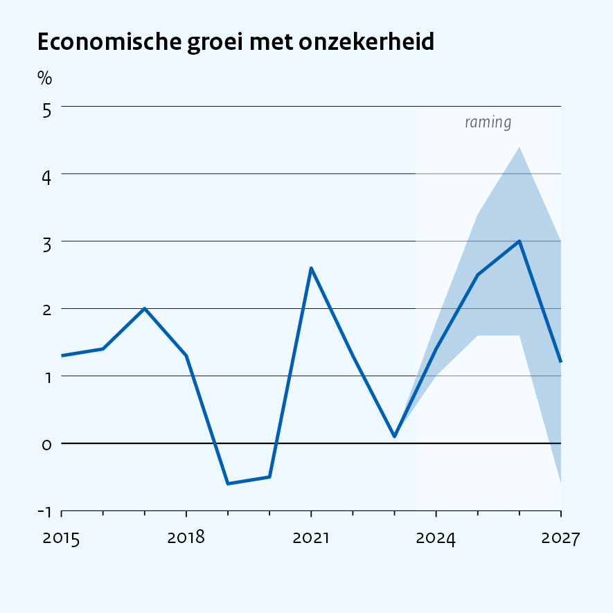

```r
groeipad <- tibble(jaar = 2015:2027,
                   groei = round(rnorm(13, 1.5, 0.8), 1)) |>
  mutate(marge = c(rep(0, 9), 0.4, 0.9, 1.4, 1.8),
         lo = groei - marge, hi = groei + marge)

cpb_line(groeipad, x = jaar, y = groei, ymin = lo, ymax = hi,
  forecast_x = 2023.5,
  title = "Economische groei met onzekerheid",
  ylab  = "%") +
  scale_x_continuous(breaks = seq(2015, 2027, 3), minor_breaks = 2015:2027,
                     guide = guide_axis(minor.ticks = TRUE))
```

The window is drawn *underneath* the data and the label is centred in it at the top of the panel; for bar charts pick a `forecast_x` between two bars (e.g. `2025.5`) so no bar is cut.

# Language style (`style = "english"`)

All plot wrappers accept `style = "english"` (default `"dutch"`). Passing `style = "english"` uses English number formatting (`,` thousands separator, `.` decimal mark) and updates house annotation labels:

- Secondary-axis legend suffixes change from `"(linkeras)"` / `"(rechteras)"` to `"(left axis)"` / `"(right axis)"`.
- Forecast window labels change from `"raming"` to `"forecast"`.

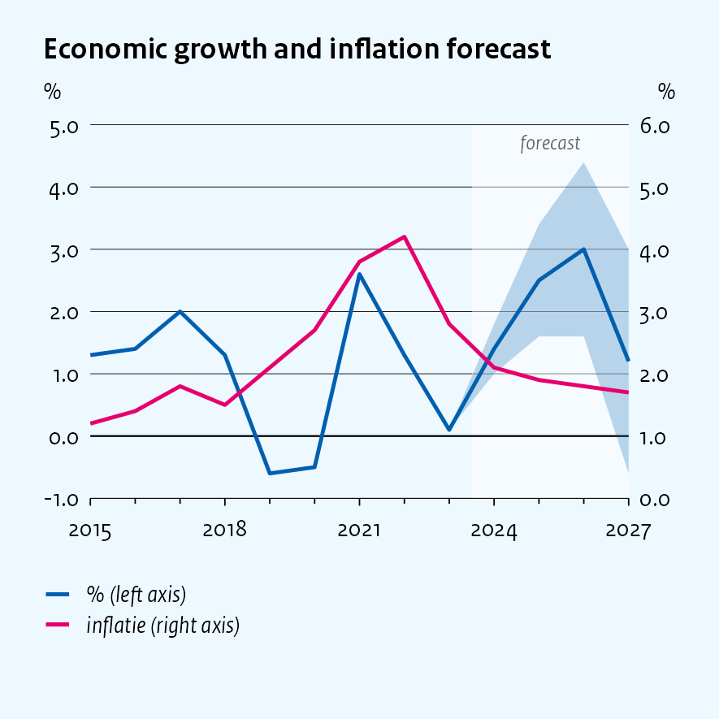

```r
# English style: decimal point (1.5), forecast label ("forecast") and dual axis ("(left axis)" / "(right axis)")
groeipad_sec <- dplyr::mutate(
  groeipad,
  inflatie = c(1.2, 1.4, 1.8, 1.5, 2.1, 2.7, 3.8, 4.2, 2.8, 2.1, 1.9, 1.8, 1.7)
)

cpb_line(groeipad_sec, x = jaar, y = groei, ymin = lo, ymax = hi,
  sec_y = inflatie, forecast_x = 2023.5,
  value_accuracy = 0.1, sec_accuracy = 0.1, style = "english",
  title = "Economic growth and inflation forecast",
  ylab = "%", sec_ylab = "%") +
  scale_x_continuous(breaks = seq(2015, 2027, 3), minor_breaks = 2015:2027,
                     guide = guide_axis(minor.ticks = TRUE))
```

# Composing: a line over stacked columns

Because every wrapper returns a real `ggplot`, a decomposition chart – stacked contribution columns with the total drawn as a line – is just `cpb_col()` plus a `geom_line()` layer and a colour scale for the extra series:

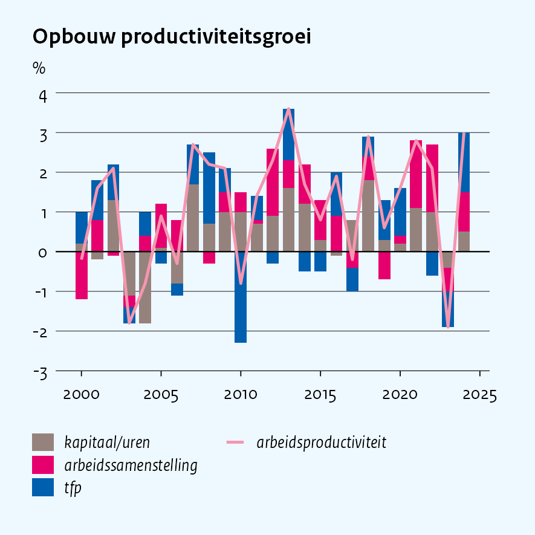

```r
componenten <- c("kapitaal/uren", "arbeidssamenstelling", "tfp")
dec <- expand_grid(jaar = 2000:2024,
                   # reversed levels stack the first component nearest zero
                   component = factor(componenten, levels = rev(componenten))) |>
  mutate(bijdrage = round(rnorm(n(), mean = 0.4, sd = 0.9), 1))
totaal <- dec |>
  summarise(bijdrage = sum(bijdrage), .by = jaar)

cpb_col(dec, x = jaar, y = bijdrage, fill = component,
  position = "stack",
  colour_index = c(2, 5, 6),
  width    = 0.75,
  title    = "Opbouw productiviteitsgroei",
  ylab     = "%") +
  geom_line(
    data    = totaal,
    mapping = aes(x = jaar, y = bijdrage, colour = "arbeidsproductiviteit"),
    linewidth = 0.55, inherit.aes = FALSE
  ) +
  scale_colour_cpb_manual(index = 1) +
  labs(colour = NULL) +
  guides(fill   = guide_legend(reverse = TRUE, order = 1),
         colour = guide_legend(order = 2)) +
  theme(legend.box = "horizontal", legend.box.just = "top")
```

# Keeping the legend’s space

A figure without a legend gives its panel the room the legend would take, so it comes out taller than the stacked chart above. In a publication the figures of one spread should line up. With `legend = "filled-empty"` no legend is drawn, but its space stays empty, so this histogram has the same panel height as a figure with a legend:

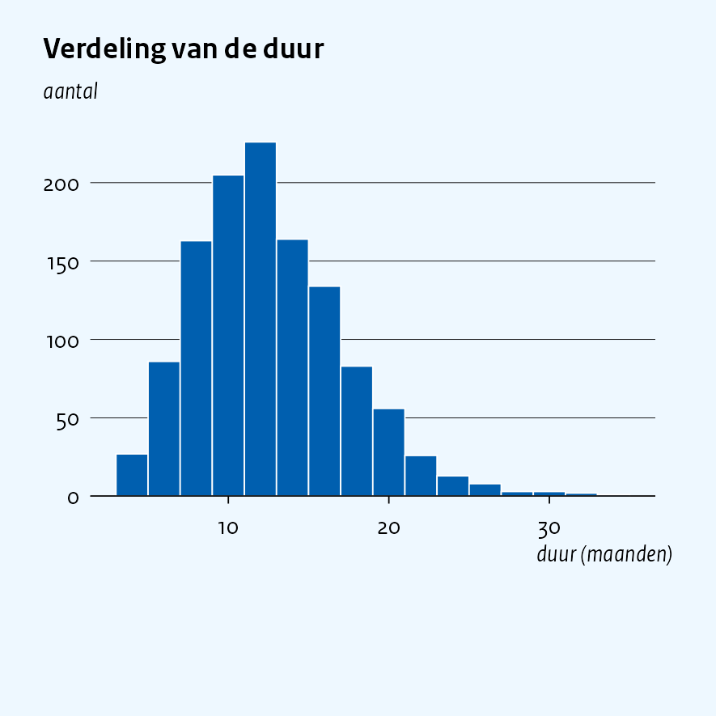

```r
duur <- tibble(maanden = round(rgamma(1200, 8, 0.6)))

cpb_hist(duur, x = maanden, binwidth = 2,
  legend = "filled-empty",
  title  = "Verdeling van de duur",
  ylab   = "aantal",
  xlab   = "duur (maanden)")
```

# Everything is a ggplot object

The wrappers do not draw anything – they *return* a `ggplot` object with the theme and scales already applied. That means the full `ggplot2` grammar stays available through `+`: extra geoms, annotations, scale tweaks and further `theme()` overrides all layer on top of what the wrapper built.

A dashed reference line with an italic annotation, on top of a horizontal bar chart:

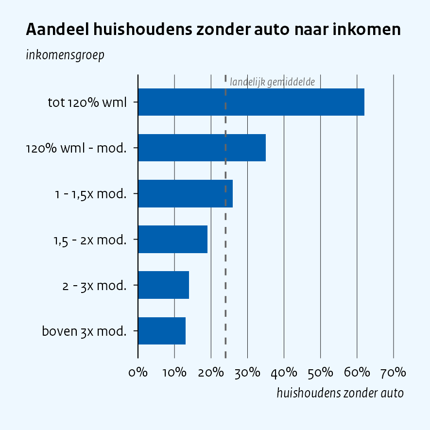

```r
cpb_col(auto, x = inkomensgroep, y = share,
  orientation  = "horizontal",
  pct_axis     = TRUE,
  value_limits = c(0, 70),
  width        = 0.6,
  title = "Aandeel huishoudens zonder auto naar inkomen",
  ylab  = "inkomensgroep",
  xlab  = "huishoudens zonder auto") +
  geom_hline(yintercept = 24, linetype = "dashed",
             colour = "#666666", linewidth = 0.4) +
  annotate("text", x = 6.45, y = 24, label = "landelijk gemiddelde",
           hjust = -0.05, size = 2.0, colour = "#666666",
           family = cpb_font_family(), fontface = "italic")
```

Note that under `coord_flip()` the value axis is still the `y` aesthetic, so a reference line on the value axis is a `geom_hline()`.

Or mark a forecast window on a line chart with a shaded region drawn by hand, as an alternative to the `forecast_x` argument above:

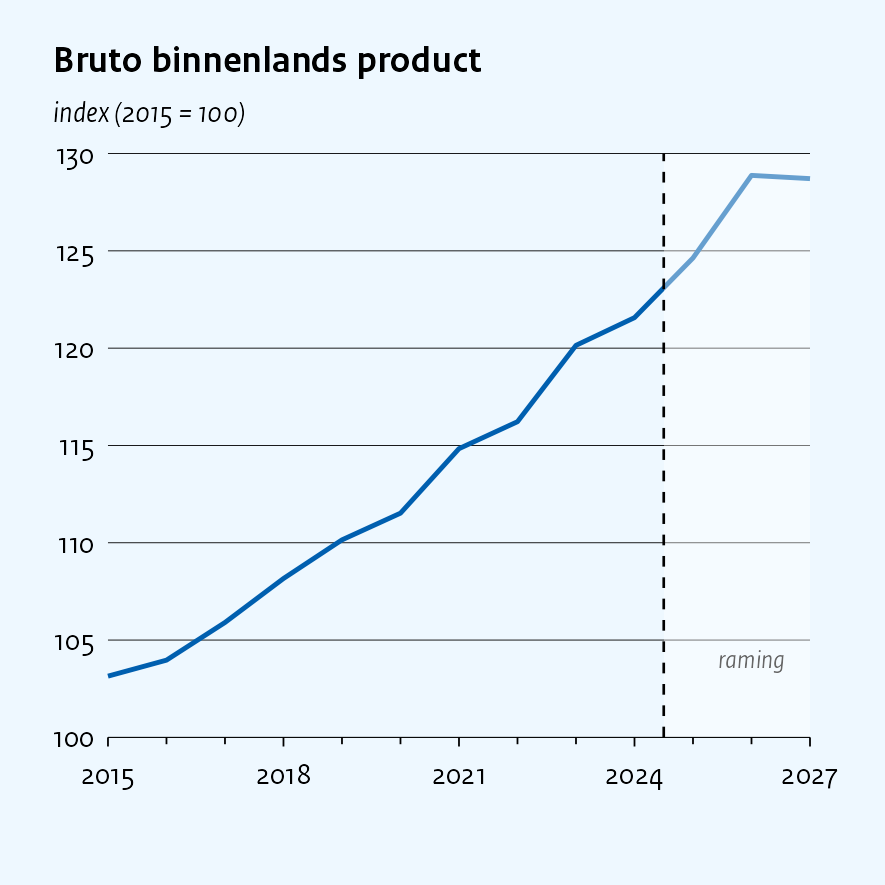

```r
cpb_line(bbp, x = jaar, y = index,
  title = "Bruto binnenlands product",
  ylab  = "index (2015 = 100)") +
  annotate("rect", xmin = 2024.5, xmax = Inf, ymin = -Inf, ymax = Inf,
           fill = "white", alpha = 0.4) +
  annotate("text", x = 2026, y = 104, label = "raming",
           size = 2.2, colour = "#666666",
           family = cpb_font_family(), fontface = "italic") +
  geom_vline(xintercept = 2024.5, linetype = "dashed", linewidth = 0.3) +
  scale_x_continuous(breaks = seq(2015, 2027, 3), minor_breaks = 2015:2027,
                     guide = guide_axis(minor.ticks = TRUE))
```

Later `+ theme(...)` calls override individual elements of `theme_cpb()` the same way – see the per-figure margin and legend tweaks in `inst/examples/smoke_test_plots.R`. The one thing *not* to add is a second value-axis scale: use the wrapper’s `value_breaks`, `value_limits` and `pct_axis` arguments instead.

For building figures entirely from the composable core (no wrappers at all), see `vignette("ggcpb")`.

Export at the CPB page sizes is covered in `vignette("ggcpb")`.